# 12 Probabilidad Condicional y Marginal, Total y Teoréma de Bayes.

2024-04-09

## Análisis de datos I (MAT1409)

## 4 Introducción a la Probabilidad

## Tema 4.9 Probabilidad Condicional

- La probabilidad de que ocurra un evento \(A\) data que ha ocurrido \(B\), se denota como \(P(A|B)\).
- La probabilidad condicional de \(A\) dado \(B\):

  \[ P(A | B) = \frac{P(A \cap B)}{P(B)} \]

## Tema 4.9 Probabilidad Condicional, Ejemplo (1/1)

- Lanza un par de dados justos.

  \(B = \{ \text{la suma es 6} \} = \{(1,5), (2,4), (3,3), (4,2), (5,1)\}\)

  y \(A = \{\text{2 en al menos un dado}\} = \{(2,4), (4,2)\}\),
- Encuentra la probabilidad de que salga un 2 dado que la suma de los dados es 6 \(P(A | B)\).

## Tema 4.9 Probabilidad Condicional Diagrama (1/2)

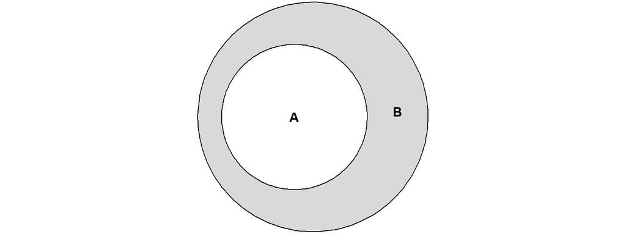

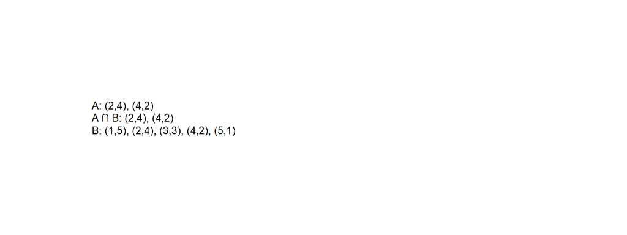

## Tema 4.9 Probabilidad Condicional, Ejemplo (1/3)

- \(E\) consta de cinco elementos y dos de ellos, (2,4) y (4,2), pertenecen a \(A\):

  \(A \cap B = \{(2,4), (4,2)\}\). Entonces \(P(A | B) = 2/5\).

## Tema 4.9 Probabilidad Condicional, Ejemplo (1/2)

Una tienda vende productos electrónicos como un mouse y productos de moda como un mousepad. La tienda ha realizado un análisis de las compras de sus clientes y ha recopilado la siguiente tabla de frecuencias:

|  | Mouse (A) | Mousepad (B) | Total(N) |
| --- | --- | --- | --- |
| Clientes que Compraron | 70 | 50 | 100 |

Con la frecuencia la probabilidad empírica esta data de la siguiente forma:

- \(P(A)=\frac{70}{100}=0.7\): Probabilidad de comprar un mouse.
- \(P(B)=\frac{50}{100}=0.5\): Probabilidad de comprar un mousepad.

## Tema 4.9 Probabilidad Condicional, Ejemplo (2/1)

- Si 30 clientes además de comprar un Mouse (A) compraron a la vez un Mousepad (B)
- ¿Cuál es la \(P(A \cap B)\) y cual es la probabilidad de comprar un Mousepad dado que compraron un mouse \(P(B | A)\)?
- ¿son \(A\) y \(B\) mutuamente excluyentes?
- ¿son \(A\) y \(B\) eventos independientes?

## Tema 4.9 Probabilidad Condicional, Ejemplo (2/3)

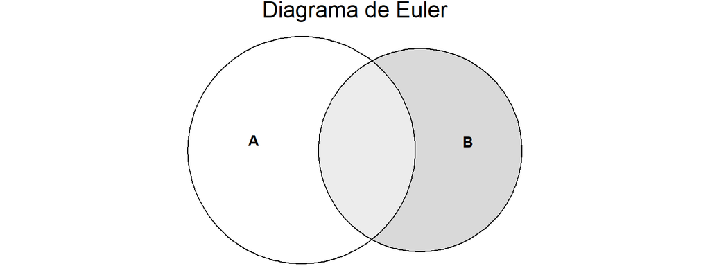

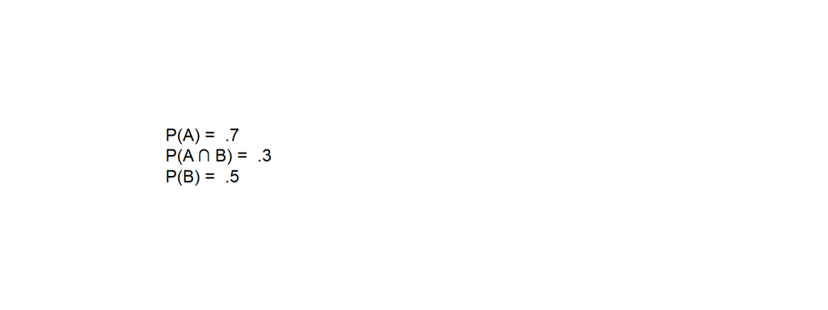

## Tema 4.9 Probabilidad Condicional, Ejemplo (2/4)

Primero la probabilidad de la intersección de \(A\) y \(B\): - \(P(A \cap B)=\frac{30}{100}=.3\)

Queremos calcular la probabilidad de que un cliente que compra un mouse también compre un mousepad (\(P(B | A)\)).

Usando la fórmula de probabilidad condicional:

\[ P(B | A) = \frac{P(A \cap B)}{P(A)} = \frac{0.3}{0.7} = 0.43 \]

Esto significa que, dado que un cliente compró un mouse, hay aproximadamente un 43% de probabilidad de que también compre un mousepad.

## Tema 4.9 Probabilidad Condicional, Ejemplo (2/5)

- ¿son \(A\) y \(B\) mutuamente excluyentes?

Debido a que \(P(A \cap B) \neq 0\), entonces comparten un area del espacio muestral y no son mutuamente excluyentes.

- ¿son \(A\) y \(B\) eventos independientes?

Para determinar si los eventos \(A\) y \(B\) son independientes, podemos verificar si se cumple la siguiente igualdad:

\[P(A \cap B) = P(A) \cdot P(B)=0.7 \cdot 0.5=0.35\]

En este caso, como \(0.3 \neq 0.35\), podemos concluir que los eventos \(A\) y \(B\) no son independientes.

## Tema 4.9 Probabilidad Condicional, Ejemplo (3/1)

Imagina que eres el gerente de un supermercado y estás interesado en entender el comportamiento de compra de tus clientes. Has recopilado la siguiente información:

- De 100 clientes, 60 compraron manzanas (evento **A**) y 50 compraron naranjas (evento **B**).
- De los clientes que compraron manzanas, 20 también compraron naranjas.

## Tema 4.9 Probabilidad Condicional, Ejemplo (3/2)

Podemos representar esta información en la siguiente tabla de frecuencias:

|  | Manzanas (A) | Naranjas (B) | Total(N) |
| --- | --- | --- | --- |
| Clientes que Compraron | 60 | 50 | 100 |

Con la frecuencia, la probabilidad empírica se calcula de la siguiente forma:

- \(P(A)=\frac{60}{100}=0.6\): Probabilidad de comprar manzanas.
- \(P(B)=\frac{50}{100}=0.5\): Probabilidad de comprar naranjas.
- 20 clientes compraron tanto manzanas (\(A\)) como naranjas (\(B\)).

## Tema 4.9 Probabilidad Condicional, Ejemplo (3/3)

**¿Cuál es la probabilidad de comprar naranjas dado que compraron manzanas?**

1. La probabilidad de la intersección de **A** y **B** (\(P(A \cap B)\)) es:

   \[P(A \cap B) = \frac{20}{100} = 0.2\]
2. La probabilidad de comprar naranjas dado que compraron manzanas (\(P(B | A)\)) se puede calcular utilizando la fórmula de probabilidad condicional:

   \[P(B | A) = \frac{P(A \cap B)}{P(A)} = \frac{0.2}{0.6} \approx 0.33\]

## Tema 4.9 Probabilidad Condicional, Ejemplo (3/4)

Para determinar si los eventos **A** y **B** son independientes, podemos verificar si se cumple la siguiente igualdad:

\[P(A \cap B) = P(A) \cdot P(B)\]

En este caso, como \(0.2 \neq 0.6 \cdot 0.5\), podemos concluir que los eventos **A** y **B** no son independientes.

## Tema 4.10 Probabilidad Marginal

- La **probabilidad marginal** es la probabilidad de un evento sin tener en cuenta el resultado de otros eventos. Se calcula sumando las probabilidades de todos los eventos que incluyen el evento de interés.

Por ejemplo, en el contexto del supermercado:

- La probabilidad de comprar manzanas (evento **A**) se calcula sumando las probabilidades de todos los eventos en los que se compran manzanas (es decir, los clientes que compraron solo manzanas y los que compraron tanto manzanas como naranjas). Esto nos da una probabilidad marginal para **A** de:

  \[P(A) = \frac{60}{100} = 0.6\]

## Tema 4.10 Probabilidad Marginal

- De manera similar, la probabilidad de comprar naranjas (evento **B**) se calcula sumando las probabilidades de todos los eventos en los que se compran naranjas (es decir, los clientes que compraron solo naranjas y los que compraron tanto naranjas como manzanas). Esto nos da una probabilidad marginal para **B** de:

  \[P(B) = \frac{50}{100} = 0.5\]

|  | Manzanas (A) | Naranjas (B) | Total(N) |
| --- | --- | --- | --- |
| Clientes que Compraron | 60 | 50 | 100 |
| Probabilidad Marginal | 0.6 | 0.5 | 1 |

## Tema 4.10 Probabilidad Marginal, Ejemplo (1/1)

Supongamos que tienes una bolsa con 100 canicas: 30 rojas, 40 azules y 30 verdes. Si eliges una canica al azar, las probabilidades marginales de elegir una canica de cada color son:

\(P(\text{Roja}) = \frac{30}{100} = 0.3)\) \(P(\text{Azul}) = \frac{40}{100} = 0.4)\) \(P(\text{Verde}) = \frac{30}{100} = 0.3)\)

- Ahora, supongamos que algunas de las canicas están marcadas con una \(X\): 10 rojas, 5 azules y 5 verdes.
- **Si se selecciona una canica al azar y resulta ser marcada, ¿cuál es la probabilidad de que esa canica sea roja?**

## Tema 4.10 Probabilidad Marginal, Ejemplo (1/2)

- Queremos calcular la probabilidad de que sea roja \(P(\text{Roja})\) dado que salió marcada \(P(\text{X})\).
- Necesitamos la formula de probabilidad condicional:

\[ P(Roja | X) = \frac{P(Roja \cap X)}{P(X)} \]

- Donde la \(P(X)\), es la probilidad marginal definida como la suma de probabilidades de sacar una bola marcada de cada color:

\[(\frac{10}{100}+\frac{5}{100}+\frac{5}{100})=\frac{2}{10}=.2\]

## Tema 4.10 Probabilidad Marginal, Ejemplo (1/2)

- En tabla la probabilidad marginal:

|  | Roja (A) | Azul (B) | Verde (C) | Marcada (X) | Total(N) |
| --- | --- | --- | --- | --- | --- |
| Canicas | 30 | 40 | 30 | 20 | 100 |
| Probabilidad Marginal | 0.3 | 0.4 | 0.3 | 0.2 | 1 |

- La probabilidad de que sea roja y marcada \[P(Roja \cap X) = \frac{10}{100}=0.1\]

## Tema 4.10 Probabilidad Marginal, Ejemplo (1/3)

- La probabilidad de que sea roja \(P(\text{Roja})\) dado que salió marcada \(P(\text{X})\). \[ P(Roja | X) = \frac{P(Roja \cap X)}{P(X)}= \frac{0.1}{0.2}=0.5 \]

## Tema 4.10 Probabilidad Marginal, Ejemplo (2/1)

Supongamos que eres el gerente de una tienda de ropa y tienes 100 clientes: 30 compraron camisas (evento A), 40 compraron pantalones (evento B) y 30 compraron zapatos (evento C). Si un cliente hace una compra al azar, las probabilidades marginales de comprar cada tipo de ropa son:

- \(P(\text{Camisa}) = \frac{30}{100} = 0.3\)
- \(P(\text{Pantalones}) = \frac{40}{100} = 0.4\)
- \(P(\text{Zapatos}) = \frac{30}{100} = 0.3\)

Algunos de los clientes son miembros de un programa de lealtad (marcados con una X): 10 que compraron camisas, 5 que compraron pantalones y 5 que compraron zapatos.

## Tema 4.10 Probabilidad Marginal, Ejemplo (2/2)

Si un cliente hace una compra al azar y resulta ser miembro del programa de lealtad, ¿cuál es la probabilidad de que ese cliente haya comprado una camisa?

- Queremos calcular la probabilidad de que compre una camisa \(P(\text{Camisa})\) dado que es miembro del programa de lealtad \(P(\text{X})\).
- Necesitamos la fórmula de probabilidad condicional:

\[ P(\text{Camisa} | X) = \frac{P(\text{Camisa} \cap X)}{P(X)} \]

- Donde \(P(X)\), es la probabilidad marginal definida como la suma de las probabilidades de que un cliente miembro del programa de lealtad compre cada tipo de ropa:

\[(\frac{10}{100}+\frac{5}{100}+\frac{5}{100})=\frac{2}{10}=0.2\]

## Tema 4.10 Probabilidad Marginal, Ejemplo (2/2)

- En la tabla, la probabilidad marginal:

|  | Camisa (A) | Pantalones (B) | Zapatos (C) | Miembro (X) | Total(N) |
| --- | --- | --- | --- | --- | --- |
| Clientes | 30 | 40 | 30 | 20 | 100 |
| Probabilidad Marginal | 0.3 | 0.4 | 0.3 | 0.2 | 1 |

- La probabilidad de que compre una camisa y sea miembro \[P(\text{Camisa} \cap X) = \frac{10}{100}=0.1\]

## Tema 4.10 Probabilidad Marginal, Ejemplo (2/3)

- La probabilidad de que compre una camisa \(P(\text{Camisa})\) dado que es miembro \(P(\text{X})\). \[ P(\text{Camisa} | X) = \frac{P(\text{Camisa} \cap X)}{P(X)}= \frac{0.1}{0.2}=0.5 \]

## 4.11 Regla de la Probabilidad Total

La regla de la probabilidad total nos permite calcular la probabilidad de un evento A, considerando la ocurrencia de otro eventos mutuamente excluyentes \(B_i\) que particionan el espacio muestral de forma exhaustiva.

La probabilidad de \(A\) es la suma de las probabilidades de \(A\) dado que cada uno de los eventos B (o subconjuntos exhaustivos mutuamente excluyentes) ocurran.

** Ecuación de la Regla de la Probabilidad Total**

\[ P(A) = \sum_{i=1}^{n} P(A|B_i)P(B_i) \]

Dónde:

- \(P(A)\) es la probabilidad del evento A.
- \(P(A|B_i)\) es la probabilidad condicional de A dado que ocurre Bi.
- \(P(B_i)\) es la probabilidad del evento Bi.
- La sumatoria se extiende a todos los eventos B_i mutuamente excluyentes que forman un conjunto exhaustivo.

## 4.11 Regla de la Probabilidad Total, Gráfica

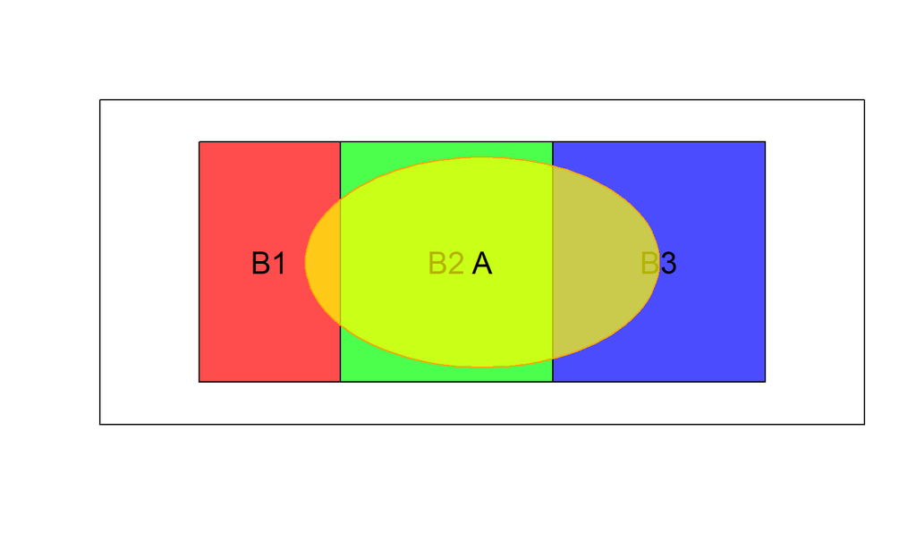

## 4.11 Regla de la Probabilidad Total, Ejemplo (1/1)

Una gran empresa de comercio electrónico está lanzando una nueva campaña de marketing para promover su línea de productos ecológicos. Están interesados en estimar la efectividad general de la campaña para impulsar las ventas.

## 4.11 Regla de la Probabilidad Total, Ejemplo (1/2)

La empresa identificó tres segmentos de clientes que probablemente estén interesados en productos ecológicos:

- **Segmento A:** Clientes preocupados por el medio ambiente (**P(Compra|A)** = 10%)
- **Segmento B:** Clientes preocupados por la salud (**P(Compra|B)** = 8%)
- **Segmento C:** Clientes preocupados por el precio (**P(Compra|C)** = 3%)

## 4.11 Regla de la Probabilidad Total, Ejemplo (1/3)

### Distribución de Segmentos de Clientes

También estimaron la proporción de clientes en cada segmento:

- **Segmento A:** 20% (**P(A)** = 0.2)
- **Segmento B:** 30% (**P(B)** = 0.3)
- **Segmento C:** 50% (**P(C)** = 0.5)

¿Cuál es la probabilidad general de que un cliente compre un producto ecológico después de la campaña de marketing (**P(Compra)**)?

## 4.11 Regla de la Probabilidad Total, Ejemplo (1/4)

**Ecuación:**

\[P(A) = \sum_{i=1}^{n} P(A|B_i) P(B_i)\]

**Donde:**

- \(P(A)\) es la probabilidad del evento A (comprar un producto ecológico).
- \(P(A|B_i)\) es la probabilidad del evento A (comprar) dado la condición \(B_i\) (segmento de cliente).
- \(P(B_i)\) es la probabilidad de la condición \(B_i\) (segmento de cliente).
- La sumatoria se extiende a todos los segmentos de clientes (n).

## Cálculo

```r
(0.10)*(0.2) + (0.08)*(0.3) + (0.03)*(0.50)
```

```
## [1] 0.059
```

## 4.12 Teorema de Bayes

Imagine que es propietario de una tienda que vende ropa. Dispones de un programa de loyalty cards donde los clientes pueden registrarse para recibir ofertas y descuentos especiales. Uno de tus artículos más vendidos es un par de jeans. Los jeans son populares y tienen un alto margen de beneficio, por lo que le interesa especialmente comprender el comportamiento de compra en torno a este producto.

## 4.12 Teorema de Bayes (1/1)

- La probabilidad de que un cliente sea miembro de tu programa de lealtad, \[P(A) = 0.5\].
- La probabilidad de que un cliente compre un par de jeans, \[P(B) = 0.1\].
- La probabilidad de que un cliente sea miembro de tu programa de lealtad dado que compró un par de jeans, \[P(A|B) = 0.2\].

## 4.12 Teorema de Bayes (2/1)

1. **Probabilidad Condicional**

   La probabilidad del evento A dado el evento B se define como:

   \[P(A|B) = \frac{P(A \cap B)}{P(B)}\]
2. **Estimando la Intersección**

   Podemos reorganizar la fórmula para encontrar la probabilidad de la intersección de A y B:

   \[P(A|B) \cdot P(B) = P(A \cap B)\]

## 4.12 Teorema de Bayes (3/1)

1. **Sustituyendo la Intersección**

   Finalmente, sustituimos la intersección en la fórmula de probabilidad condicional para obtener el teorema de Bayes:

   \[P(B|A) = \frac{P(A|B) \cdot P(B)}{P(A)}\]

## Revisión

```
## Versión: 18/04/2024
```

## Bibliografía

- Dodge, Y. (2008). The concise encyclopedia of statistics. Springer Science & Business Media.
- Business Mathematics.(2023).SBPD https://www.google.com.mx/books/edition/Business_Mathematics/oRLFEAAAQBAJ
- Smith, G. (2015). *Essential statistics, regression, and econometrics.*
- Spiegel, M. R., Srinivasan, R. A., & Schiller, J. J. (2000). Schaum’s outline of theory and problems of probability and statistics. Erlangga.